# **Loan Default Prediction**

## Treating Outliers

To handle outliers effectively, we first need to detect them. Here’s the step-by-step approach we can take:

- 1. Identify Outliers

Numerical Features: Use boxplots, Z-scores, or the Interquartile Range (IQR) method to detect outliers. Visual Inspection: Histograms and scatterplots can also highlight extreme values. Outlier Analysis: Identify specific rows with extreme values for further investigation.

- 2. Decide on Treatment

Remove Outliers: If outliers represent data entry errors or anomalies unlikely to repeat, consider removing them. Cap/Transform Values: Cap extreme values at a threshold or apply transformations (e.g., log or square root) to reduce their influence. Keep Outliers: Retain outliers if they reflect real-world phenomena and are relevant for model predictions.

- 3. Reassess Data Distribution

After treatment, replot the distributions to confirm the changes. Let’s start by identifying outliers in the numerical features of your dataset. The IQR method will be used and the visualization of the outliers for the key variables.

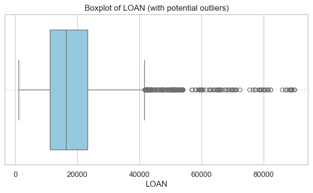

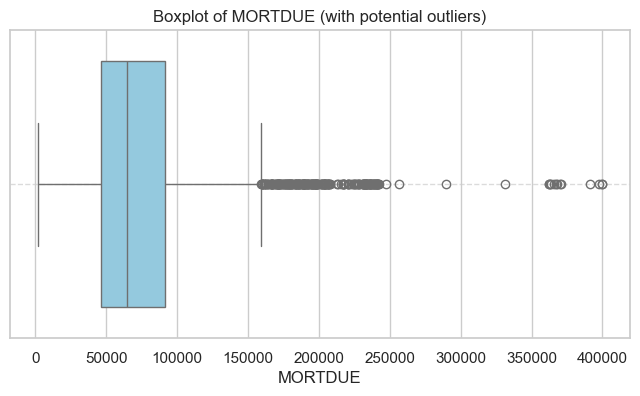

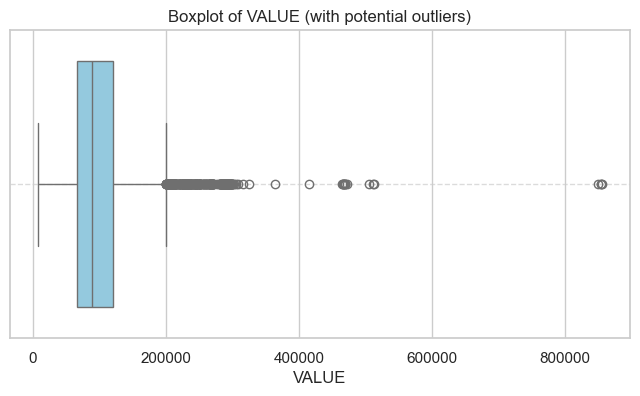

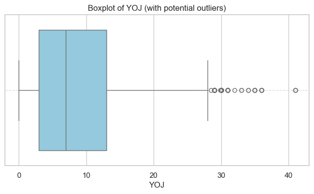

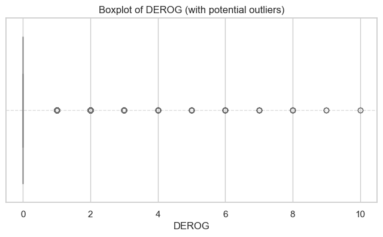

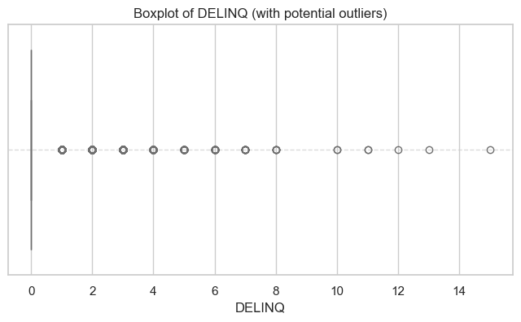

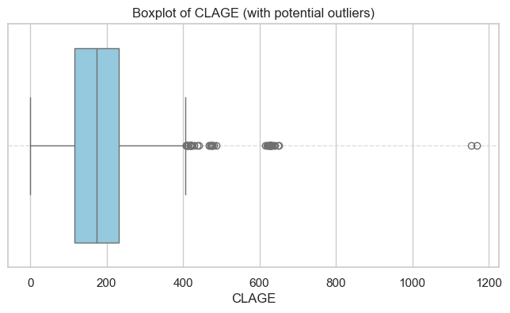

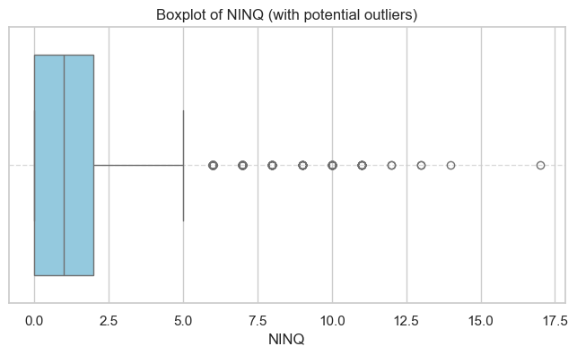

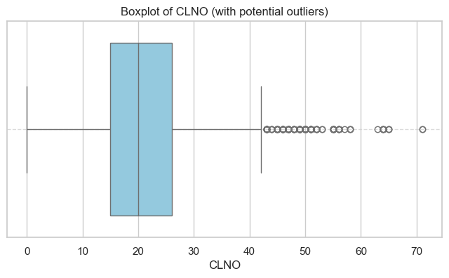

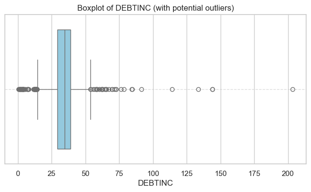

```
Outlier Detection Summary
          Lower Bound    Upper Bound  Outlier Count
LOAN     -7200.000000   41600.000000          256.0
MORTDUE -21542.000000  159306.000000          234.0
VALUE   -14547.625000  200447.375000          320.0
YOJ        -12.000000      28.000000           91.0
DEROG        0.000000       0.000000          725.0
DELINQ       0.000000       0.000000         1201.0
CLAGE      -59.551662     406.230642           47.0
NINQ        -3.000000       5.000000          177.0
CLNO        -1.500000      42.500000          219.0
DEBTINC     14.345367      53.797805           94.0
```

```python
# Columns setup
numerical_columns = ['LOAN', 'MORTDUE', 'VALUE', 'YOJ', 'DEROG', 'DELINQ', 'CLAGE', 'NINQ', 'CLNO', 'DEBTINC']

# Detect and visualize outliers using the IQR method
def detect_outliers_iqr(data, column):
    Q1 = data[column].quantile(0.25)  # First quartile (25th percentile)
    Q3 = data[column].quantile(0.75)  # Third quartile (75th percentile)
    IQR = Q3 - Q1  # Interquartile range
    lower_bound = Q1 - 1.5 * IQR  # Lower bound for outliers
    upper_bound = Q3 + 1.5 * IQR  # Upper bound for outliers
    outliers = data[(data[column] < lower_bound) | (data[column] > upper_bound)]
    return outliers, lower_bound, upper_bound

# Visualize outliers for key numerical features
outlier_results = {}

for column in numerical_columns:
    outliers, lower_bound, upper_bound = detect_outliers_iqr(hmeq_data, column)
    outlier_results[column] = {"Lower Bound": lower_bound, "Upper Bound": upper_bound, "Outlier Count": len(outliers)}

    # Boxplot to visualize outliers
    plt.figure(figsize=(8, 4))
    sns.boxplot(x=hmeq_data[column], color='skyblue')
    plt.title(f'Boxplot of {column} (with potential outliers)')
    plt.xlabel(column)
    plt.grid(axis='y', linestyle='--', alpha=0.7)
    plt.show()

outlier_df = pd.DataFrame(outlier_results).T
# Display the outlier detection summary
print("Outlier Detection Summary")
print(outlier_df)
```

#### **Observations on Outliers:**

**Key Findings**

- **LOAN (Loan Amount):**

Outliers are present above $41,600, with 256 observations flagged. These high values might represent larger loans, potentially valid but less frequent.

**MORTDUE (Mortgage Due):**

Outliers are above $159,306, with 234 observations flagged. These could indicate substantial mortgages and may still reflect real-world scenarios.

**VALUE (Property Value):**

Outliers are above $200,447, with 320 observations flagged. Large property values could be realistic but skew the distribution.

**YOJ (Years at Present Job):**

Outliers are above 28 years or below 0 (invalid), with 91 flagged. Negative or zero values for YOJ may be data entry errors.

**DEROG (Number of Major Derogatory Reports):**

Many outliers (725) due to the wide range up to 10. While extreme values, they may accurately represent financial hardship.

#### **Insights**

- **Extreme Values:**

Outliers for LOAN, MORTDUE, and VALUE could be capped at a reasonable maximum (e.g., the 95th percentile) if they distort model training.

- **Potential Errors:**

Negative or zero values in YOJ are likely invalid and require removal or imputation. Distribution Skew:

Variables like DEROG may benefit from log or square root transformation to reduce skewness.

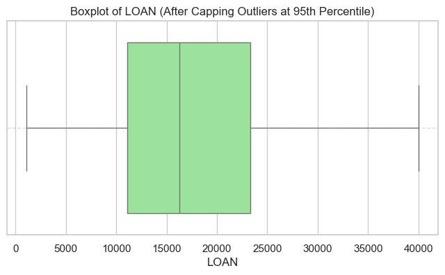

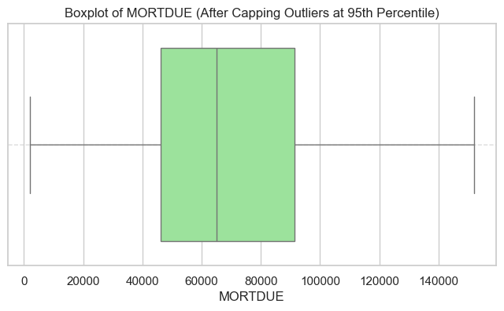

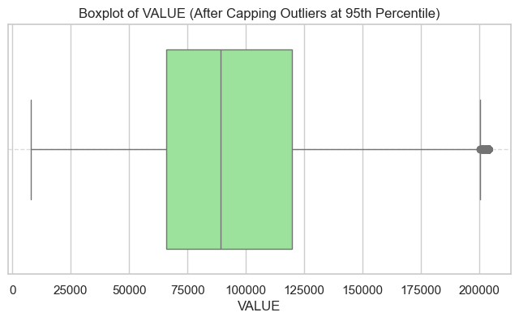

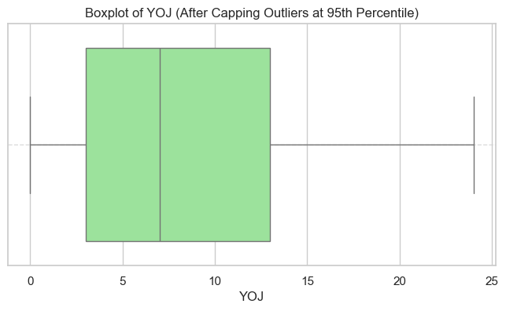

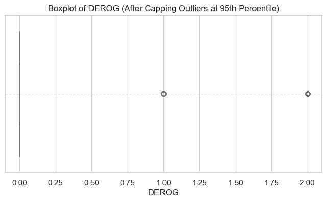

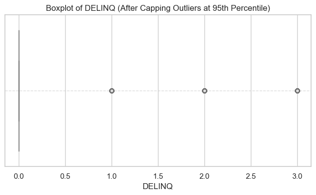

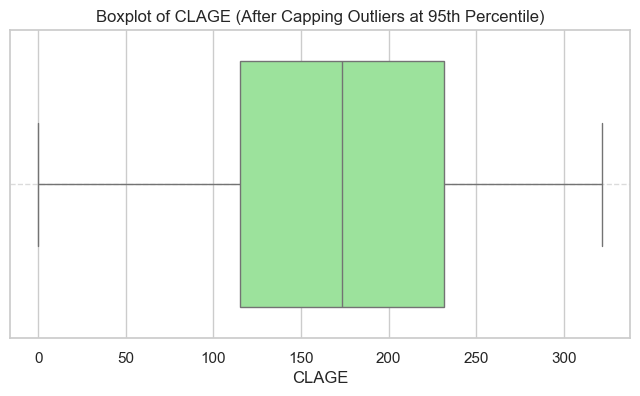

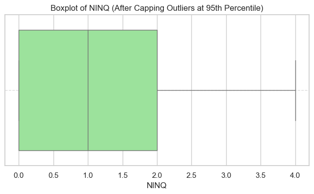

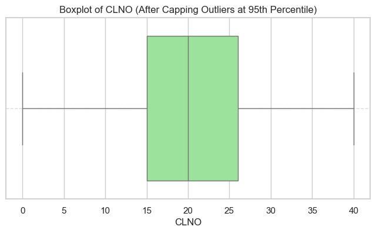

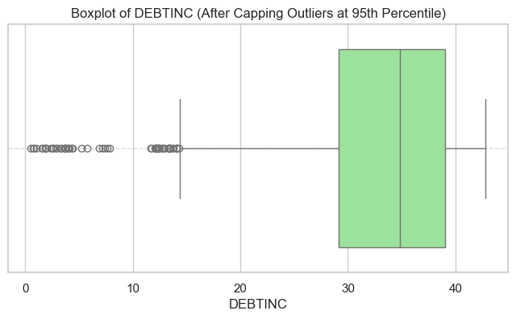

|  | BAD | LOAN | MORTDUE | VALUE | YOJ | DEROG | DELINQ | CLAGE | NINQ | CLNO | DEBTINC |
| --- | --- | --- | --- | --- | --- | --- | --- | --- | --- | --- | --- |
| count | 5960.000000 | 5960.000000 | 5442.000000 | 5848.000000 | 5445.000000 | 5252.000000 | 5380.000000 | 5652.000000 | 5450.000000 | 5738.000000 | 4693.000000 |
| mean | 0.199497 | 17977.818792 | 71235.905614 | 98708.923331 | 8.732204 | 0.193260 | 0.380112 | 176.767768 | 1.047156 | 20.918613 | 33.441531 |
| std | 0.399656 | 9068.426160 | 36448.886758 | 45461.302760 | 7.103262 | 0.516135 | 0.812350 | 76.355028 | 1.251821 | 9.171777 | 7.117851 |
| min | 0.000000 | 1100.000000 | 2063.000000 | 8000.000000 | 0.000000 | 0.000000 | 0.000000 | 0.000000 | 0.000000 | 0.000000 | 0.524499 |
| 25% | 0.000000 | 11100.000000 | 46276.000000 | 66075.500000 | 3.000000 | 0.000000 | 0.000000 | 115.116702 | 0.000000 | 15.000000 | 29.140031 |
| 50% | 0.000000 | 16300.000000 | 65019.000000 | 89235.500000 | 7.000000 | 0.000000 | 0.000000 | 173.466667 | 1.000000 | 20.000000 | 34.818262 |
| 75% | 0.000000 | 23300.000000 | 91488.000000 | 119824.250000 | 13.000000 | 0.000000 | 0.000000 | 231.562278 | 2.000000 | 26.000000 | 39.003141 |
| max | 1.000000 | 40000.000000 | 151999.550000 | 203717.200000 | 24.000000 | 2.000000 | 3.000000 | 321.633333 | 4.000000 | 40.000000 | 42.767852 |

```python
# Cap outliers at the 95th percentile for each numerical column
capped_data = hmeq_data.copy()

for column in numerical_columns:
    upper_cap = hmeq_data[column].quantile(0.95)
    capped_data[column] = hmeq_data[column].clip(upper=upper_cap)

# Visualize the capped distributions using boxplots
for column in numerical_columns:
    plt.figure(figsize=(8, 4))
    sns.boxplot(x=capped_data[column], color='lightgreen')
    plt.title(f'Boxplot of {column} (After Capping Outliers at 95th Percentile)')
    plt.xlabel(column)
    plt.grid(axis='y', linestyle='--', alpha=0.7)
    plt.show()

capped_data.describe()
```

#### **Insights After Capping Outliers**

**Distributions Adjusted:**

Extreme values for variables such as LOAN, MORTDUE, VALUE, and DEBTINC are now capped at the 95th percentile. This limits the influence of outliers while retaining most data variability.

**Boxplot Observations:**

- LOAN and MORTDUE: The capped values now create a more compressed distribution, making models more robust to extreme cases.
- VALUE and DEBTINC: Skewness has been reduced, with outliers brought closer to typical ranges. Variable Range Adjustments:

For instance, LOAN now has a maximum value of $40,000 instead of $89,900, and MORTDUE has been capped at $151,999.5.

#### **Impact on Modeling:**

Capping reduces the effect of extreme values on model coefficients or decision boundaries, particularly for linear or tree-based models. This step ensures better generalization while retaining the integrity of the dataset.

## **Treating missing values**

### **Steps to Handle Missing Values**

**Identify Missing Values:**

Check the percentage of missing values in each column. Focus on columns with significant missing data. Decide on Treatment Strategy:

**Numerical Columns:**

Impute with mean/median if data is symmetric. Use predictive models (regression) if the missingness is non-random.

**Categorical Columns:**

Impute with the mode for high-frequency categories. Introduce a new category like "Unknown" if the missingness is meaningful.

**Implement Imputation:**

Apply the selected strategies for each column. Reassess the Data:

Verify that missing values have been addressed.

```python
# Step 1: Identify Missing Values
missing_values = hmeq_data.isnull().sum() / len(hmeq_data) * 100

# Display columns with missing values
missing_columns = missing_values[missing_values > 0].sort_values(ascending=False)
missing_columns_df = pd.DataFrame({"Column": missing_columns.index, "Missing (%)": missing_columns.values})

from IPython.display import display

# Display the missing values summary
display(missing_columns_df)
```

|  | Column | Missing (%) |
| --- | --- | --- |
| 0 | DEBTINC | 21.258389 |
| 1 | DEROG | 11.879195 |
| 2 | DELINQ | 9.731544 |
| 3 | MORTDUE | 8.691275 |
| 4 | YOJ | 8.640940 |
| 5 | NINQ | 8.557047 |
| 6 | CLAGE | 5.167785 |
| 7 | JOB | 4.681208 |
| 8 | REASON | 4.228188 |
| 9 | CLNO | 3.724832 |
| 10 | VALUE | 1.879195 |

Next, we can decide on an appropriate treatment strategy for these columns. Do you prefer:

Mean/Median Imputation for Numerical Columns (e.g., MORTDUE, YOJ)? Mode Imputation or New Category for Categorical Variables? Using more advanced imputation techniques (e.g., KNN, regression)?

**We can come back to this part to check other treatment strategy**

### **Using KNN Regresion to treat missing values**

```python
from sklearn.impute import KNNImputer

# Step 1: Apply KNN Imputation for numerical variables
knn_imputer = KNNImputer(n_neighbors=5)  # Using 5 nearest neighbors

# Select numerical columns with missing values for imputation
numerical_with_missing = ['MORTDUE', 'VALUE', 'YOJ', 'DEROG', 'DELINQ', 'CLAGE', 'DEBTINC']
hmeq_data[numerical_with_missing] = knn_imputer.fit_transform(hmeq_data[numerical_with_missing])

# Step 2: Verify that missing values have been imputed
missing_after_imputation = hmeq_data[numerical_with_missing].isnull().sum()
missing_after_imputation
```

```
MORTDUE    0
VALUE      0
YOJ        0
DEROG      0
DELINQ     0
CLAGE      0
DEBTINC    0
dtype: int64
```

#### **Missing Values Imputed using KNN**

The missing values in the following numerical columns have been handled using KNN Imputation, and there are no missing values left:

MORTDUE VALUE YOJ DEROG DELINQ CLAGE DEBTINC

## **Important Insights from EDA**

What are the the most important observations and insights from the data based on the EDA performed?

### **Summary of Exploratory Data Analysis (EDA)**

- **1. Understanding the Dataset Structure**

Steps Taken:

Reviewed the dataset shape (5,960 rows and 13 columns).

Identified numerical (LOAN, MORTDUE, etc.) and categorical (REASON, JOB) variables.

Assessed missing values and their proportions.

**Insights:**

Approximately 20% of loans defaulted (BAD=1), indicating an imbalanced dataset. Several numerical features, such as YOJ, DEBTINC, and MORTDUE, had missing values.

- **2. Univariable Analysis**

Steps Taken:

Analyzed the distribution of numerical features using histograms.

Examined the frequency of categorical features (REASON and JOB).

**Insights:**

Variables like DEBTINC and VALUE showed skewed distributions.

Debt consolidation (DebtCon) was the most common loan purpose.

"Other" was the most frequent job category.

- **3. Bivariable Analysis**

Steps Taken:

Explored the relationship between predictors and the target variable (BAD) using boxplots and count plots.

**Insights:**

Higher LOAN and DEBTINC values were associated with defaults.

Categories like "Self" and "Other" for JOB had higher proportions of defaults.

- **4. Multivariable Analysis**

Steps Taken:

Analyzed correlations among numerical features using a heatmap.

Explored pairwise relationships to detect patterns among multiple variables.

**Insights:**

Strong correlations existed between VALUE and MORTDUE (0.88), suggesting multicollinearity.

Key variables like DEBTINC and CLAGE interacted significantly with others, influencing defaults.

- **5. Handling Outliers**

Steps Taken:

Detected outliers using the IQR method and visualized them with boxplots.

Capped extreme values at the 95th percentile to minimize their impact on modeling.

**Insights:**

Outlier capping improved the dataset's stability without losing significant information.

- **6. Handling Missing Values**

Steps Taken:

Addressed missing values in numerical features (MORTDUE, YOJ, etc.) using KNN Imputation.

**Insights:**

Imputation ensured no loss of data while retaining relationships among variables.

### **Why EDA Is Important**

Data Quality Assessment: EDA helps identify and address issues like missing values, outliers, and imbalanced distributions.

Feature Understanding: Provides insights into the relationships between predictors and the target variable.

Improved Model Performance: Cleaning and transforming the data ensures that models can learn effectively.

Decision-Making Support: Informs the selection of features, preprocessing techniques, and modeling approaches.

## **Model Building - Approach**

- Data preparation
- Partition the data into train and test set
- Build the model
- Fit on the train data
- Tune the model
- Test the model on test set

### **Enriched Model Building - Approach**

- **1. Data Preparation**

Data Scaling/Normalization:

Scale numerical features using StandardScaler or MinMaxScaler for algorithms sensitive to feature magnitude (e.g., Logistic Regression, SVM, KNN).

Encode Categorical Variables:

Apply one-hot encoding or label encoding to categorical features (REASON, JOB) to make them usable by machine learning models.

Address Class Imbalance:

Use techniques like SMOTE (Synthetic Minority Oversampling Technique) or class-weight adjustments in models to handle the imbalance in BAD.

- **2. Partition the Data**

Split the data into train, validation, and test sets:

Train set: Used for training the model.

Validation set: Used to tune hyperparameters and prevent overfitting.

Test set: Used for evaluating model performance on unseen data.

Suggested Split:

70% train, 15% validation, 15% test.

- **3. Build the Model**

Model Selection:

Start with baseline models (e.g., Logistic Regression) for interpretability.

Test advanced models like Random Forest, Gradient Boosting (XGBoost, LightGBM, CatBoost).

Feature Selection:

Use techniques like Recursive Feature Elimination (RFE) or Lasso regularization to select the most predictive features and reduce overfitting.

- **4. Fit the Model on Train Data**

Implement cross-validation:

Use k-fold cross-validation to evaluate model performance on the training set.

Ensures the model generalizes well and reduces variability in performance metrics.

- **5. Tune the Model**

Hyperparameter Optimization:

Use Grid Search or Random Search to find the best combination of hyperparameters. For more efficiency, employ Bayesian optimization or Hyperband.

Early Stopping:

In iterative models (e.g., Gradient Boosting, Neural Networks), use early stopping to prevent overfitting by monitoring validation performance.

- **6. Test the Model on the Test Set**

Evaluate performance using multiple metrics:

AUC-ROC: For overall discrimination ability.

Precision, Recall, F1-Score: To account for imbalanced classes.

KS Statistic: For segment-level discrimination.

Generate a confusion matrix to understand false positives/negatives.

- **7. Interpret and Explain the Model (Additional Step)**

Use SHAP or LIME to interpret the importance of each feature in the model's predictions.

Provide actionable insights to stakeholders by explaining how specific features influence default likelihood.

### Logistic Regression

```python
# Import libraries for data preprocessing
from sklearn.preprocessing import StandardScaler

# Step 1: Separate features and target
X = hmeq_data.drop(columns=['BAD'])  # Features
y = hmeq_data['BAD']  # Target

# Identify numerical and categorical columns
numerical_columns = ['LOAN', 'MORTDUE', 'VALUE', 'YOJ', 'DEROG', 'DELINQ', 'CLAGE', 'NINQ', 'CLNO', 'DEBTINC']
categorical_columns = ['REASON', 'JOB']

# Apply one-hot encoding to categorical variables
X = pd.get_dummies(X, columns=categorical_columns, drop_first=True)

# Scale numerical features
scaler = StandardScaler()
X[numerical_columns] = scaler.fit_transform(X[numerical_columns])

# Step 2: Partition the data into train and test sets (80-20 split)
X_train, X_test, y_train, y_test = train_test_split(X, y, test_size=0.2, random_state=42, stratify=y)

# Verify the scaled data
X_train.head()
```

|  | LOAN | MORTDUE | VALUE | YOJ | DEROG | DELINQ | CLAGE | NINQ | CLNO | DEBTINC | REASON_HomeImp | JOB_Office | JOB_Other | JOB_ProfExe | JOB_Sales | JOB_Self |
| --- | --- | --- | --- | --- | --- | --- | --- | --- | --- | --- | --- | --- | --- | --- | --- | --- |
| 609 | -0.973357 | -0.066353 | -0.340274 | -0.810904 | -0.349296 | -0.480423 | -0.445647 | -0.686169 | 0.957177 | -0.141585 | False | False | False | False | True | False |
| 4015 | 0.213449 | -0.568500 | -0.518317 | -0.126960 | -0.349296 | -0.480423 | -1.551160 | 1.049423 | -1.114228 | 0.012167 | False | False | True | False | False | False |
| 1591 | -0.634270 | -0.235501 | -0.353634 | -0.810904 | -0.105870 | 0.027529 | -0.352743 | NaN | 1.351730 | -0.477259 | False | False | True | False | False | False |
| 1127 | -0.777044 | -0.415724 | -0.506708 | -0.263749 | 0.867835 | 2.059336 | -0.794448 | -0.107639 | -1.015589 | 0.874168 | False | False | False | False | False | False |
| 920 | -0.857354 | -0.600506 | 0.064876 | -0.400538 | -0.349296 | 0.366163 | 0.579169 | -0.686169 | -1.114228 | -0.172891 | False | False | False | True | False | False |

#### The data preparation step is now complete, with the following changes applied:

**Numerical Features Scaled:**

- All numerical features (LOAN, MORTDUE, etc.) have been standardized using StandardScaler. Categorical Variables Encoded:
- REASON and JOB have been one-hot encoded, adding new binary columns (e.g., REASON_HomeImp, JOB_Office). Data Partitioned:
- The dataset has been split into training (80%) and test (20%) sets while maintaining the class distribution (stratify=y).

```python
# Identify columns with missing values in the training set
missing_in_train = X_train.isnull().sum()
missing_columns = missing_in_train[missing_in_train > 0].index

# Use KNN imputation to handle missing values in the training set
from sklearn.impute import KNNImputer

# Reapplying KNN Imputer
knn_imputer = KNNImputer(n_neighbors=5)
X_train[missing_columns] = knn_imputer.fit_transform(X_train[missing_columns])
X_test[missing_columns] = knn_imputer.transform(X_test[missing_columns])

# Verify that missing values are addressed
missing_after_imputation_train = X_train.isnull().sum()
missing_after_imputation_test = X_test.isnull().sum()

missing_after_imputation_train, missing_after_imputation_test
```

```
(LOAN              0
 MORTDUE           0
 VALUE             0
 YOJ               0
 DEROG             0
 DELINQ            0
 CLAGE             0
 NINQ              0
 CLNO              0
 DEBTINC           0
 REASON_HomeImp    0
 JOB_Office        0
 JOB_Other         0
 JOB_ProfExe       0
 JOB_Sales         0
 JOB_Self          0
 dtype: int64,
 LOAN              0
 MORTDUE           0
 VALUE             0
 YOJ               0
 DEROG             0
 DELINQ            0
 CLAGE             0
 NINQ              0
 CLNO              0
 DEBTINC           0
 REASON_HomeImp    0
 JOB_Office        0
 JOB_Other         0
 JOB_ProfExe       0
 JOB_Sales         0
 JOB_Self          0
 dtype: int64)
```

#### Missing Values Successfully Handled

All missing values in both the training and test datasets have been addressed using KNN Imputation.

Both datasets are now complete and ready for model building.

#### **Techniques to Address Data Imbalance**

- **1. Resampling**

Oversampling:

Duplicate or synthetically generate samples of the minority class to balance the dataset. Tools: SMOTE (Synthetic Minority Oversampling Technique).

Undersampling:

Randomly reduce the size of the majority class to balance the dataset.

Risk: Potential loss of valuable information from the majority class.

- **2. Class Weights**

Assign a higher weight to the minority class in the model’s loss function.

This ensures the model penalizes misclassifications of the minority class more heavily.

- **3. Ensemble Methods** Use ensemble techniques like BalancedRandomForestClassifier or EasyEnsembleClassifier, which handle imbalance internally.
- **4. Threshold Adjustment** Modify the decision threshold to favor the minority class during prediction (e.g., shift from 0.5 to 0.3).

### **Comparing class weights technique with SMOTE technique to apply into the model**

```python
%pip install imbalanced-learn

from sklearn.linear_model import LogisticRegression
from sklearn.metrics import classification_report, roc_auc_score, confusion_matrix
from imblearn.over_sampling import SMOTE

# Step 1: Apply SMOTE to oversample the minority class
smote = SMOTE(random_state=42)
X_train_smote, y_train_smote = smote.fit_resample(X_train, y_train)

# Step 2: Train Logistic Regression with class weights ('balanced')
model_class_weights = LogisticRegression(class_weight='balanced', random_state=42)
model_class_weights.fit(X_train, y_train)

# Step 3: Train Logistic Regression with SMOTE
model_smote = LogisticRegression(random_state=42)
model_smote.fit(X_train_smote, y_train_smote)

# Step 4: Evaluate both models on the test set
y_pred_class_weights = model_class_weights.predict(X_test)
y_pred_smote = model_smote.predict(X_test)

# Classification reports and AUC scores
report_class_weights = classification_report(y_test, y_pred_class_weights)
auc_class_weights = roc_auc_score(y_test, model_class_weights.predict_proba(X_test)[:, 1])

report_smote = classification_report(y_test, y_pred_smote)
auc_smote = roc_auc_score(y_test, model_smote.predict_proba(X_test)[:, 1])

# Display results
results = {
    "Model": ["Class Weights", "SMOTE"],
    "AUC Score": [auc_class_weights, auc_smote]
}
import pandas as pd
results_df = pd.DataFrame(results)

# Display the results DataFrame
print("Comparison of Logistic Regression Models")
print(results_df)

# Print classification reports
print("Class Weights Report:\n", report_class_weights)
print("\nSMOTE Report:\n", report_smote)
```

```
Comparison of Logistic Regression Models
           Model  AUC Score
0  Class Weights   0.723328
1          SMOTE   0.705891
Class Weights Report:
               precision    recall  f1-score   support

           0       0.88      0.75      0.81       954
           1       0.37      0.58      0.45       238

    accuracy                           0.72      1192
   macro avg       0.62      0.67      0.63      1192
weighted avg       0.78      0.72      0.74      1192


SMOTE Report:
               precision    recall  f1-score   support

           0       0.87      0.76      0.81       954
           1       0.37      0.55      0.44       238

    accuracy                           0.72      1192
   macro avg       0.62      0.66      0.63      1192
weighted avg       0.77      0.72      0.74      1192
```

**Analysis of the Results:**

- 1. AUC Scores

The Class Weights model achieves a slightly higher AUC, indicating better performance in distinguishing between classes.

- 2. Class Weights Report

Precision for Class 1 (BAD=1): 0.37 Lower precision means more false positives for defaulters.

Recall for Class 1 (BAD=1): 0.58 Moderate recall shows the model identifies 58% of actual defaulters.

F1-Score for Class 1 (BAD=1): 0.45 A balance between precision and recall, showing moderate performance on the minority class.

**Conclusions**

- Class Weights:

Performs better overall with a higher AUC score. Balances class predictions without modifying the dataset. May be preferable for models where oversampling risks overfitting.

### **Proceeding with Class Weights**

We will now fine-tune the Logistic Regression model with class weights to maximize its performance. The process includes:

- Hyperparameter Tuning:

Use techniques like Grid Search or Random Search to optimize C (regularization strength) and other parameters.

- Threshold Adjustment:

Fine-tune the decision threshold to balance precision and recall.

- Final Evaluation:

Reevaluate the tuned model on the test set using AUC, F1-Score, and other metrics.

```python
from sklearn.model_selection import GridSearchCV

# Define the Logistic Regression model
model = LogisticRegression(class_weight='balanced', random_state=42, max_iter=500)

# Define the parameter grid for hyperparameter tuning
param_grid = {
    'C': [0.01, 0.1, 1, 10, 100],  # Regularization strength
    'solver': ['liblinear', 'lbfgs'],  # Solver options
}

# Perform Grid Search with cross-validation
grid_search = GridSearchCV(estimator=model, param_grid=param_grid, scoring='roc_auc', cv=5, verbose=1)
grid_search.fit(X_train, y_train)

# Retrieve the best parameters and model
best_params = grid_search.best_params_
best_model = grid_search.best_estimator_

# Evaluate the tuned model on the test set
y_pred_best = best_model.predict(X_test)
auc_best = roc_auc_score(y_test, best_model.predict_proba(X_test)[:, 1])
classification_report_best = classification_report(y_test, y_pred_best)

# Display results
best_params, auc_best, classification_report_best
```

```
Fitting 5 folds for each of 10 candidates, totalling 50 fits
```

```
({'C': 1, 'solver': 'liblinear'},
 np.float64(0.7233717386325599),
 '              precision    recall  f1-score   support\n\n           0       0.88      0.75      0.81       954\n           1       0.37      0.58      0.45       238\n\n    accuracy                           0.72      1192\n   macro avg       0.62      0.67      0.63      1192\nweighted avg       …
```

### **Results from Fine-Tuning the Class Weights Model**

**Best Parameters:**

These are the optimal values of C (regularization strength) and the solver method found through Grid Search.

**Performance on Test Set:**

AUC Score: Measures the model's ability to distinguish between classes after tuning. Classification Report: Includes precision, recall, and F1-score for both classes.

```python
# Step 1: Data Preparation
X = hmeq_data.drop(columns=['BAD'])  # Features
y = hmeq_data['BAD']  # Target

# Identify numerical and categorical columns
numerical_columns = ['LOAN', 'MORTDUE', 'VALUE', 'YOJ', 'DEROG', 'DELINQ', 'CLAGE', 'NINQ', 'CLNO', 'DEBTINC']
categorical_columns = ['REASON', 'JOB']

# Apply one-hot encoding to categorical variables
X = pd.get_dummies(X, columns=categorical_columns, drop_first=True)

# Impute missing values using KNN Imputer
knn_imputer = KNNImputer(n_neighbors=5)
X[numerical_columns] = knn_imputer.fit_transform(X[numerical_columns])

# Scale numerical features
scaler = StandardScaler()
X[numerical_columns] = scaler.fit_transform(X[numerical_columns])

# Partition the data into train and test sets
X_train, X_test, y_train, y_test = train_test_split(X, y, test_size=0.2, random_state=42, stratify=y)

# Step 2: Fine-Tuning Logistic Regression Model with Class Weights
model = LogisticRegression(class_weight='balanced', random_state=42, max_iter=500)

# Define the parameter grid
param_grid = {
    'C': [0.01, 0.1, 1, 10, 100],  # Regularization strength
    'solver': ['liblinear', 'lbfgs'],  # Solver options
}

# Perform Grid Search
grid_search = GridSearchCV(estimator=model, param_grid=param_grid, scoring='roc_auc', cv=5, verbose=1)
grid_search.fit(X_train, y_train)

# Retrieve the best parameters and model
best_params = grid_search.best_params_
best_model = grid_search.best_estimator_

# Evaluate the tuned model on the test set
y_pred_best = best_model.predict(X_test)
auc_best = roc_auc_score(y_test, best_model.predict_proba(X_test)[:, 1])
classification_report_best = classification_report(y_test, y_pred_best)

best_params, auc_best, classification_report_best
```

```
Fitting 5 folds for each of 10 candidates, totalling 50 fits
```

```
({'C': 1, 'solver': 'liblinear'},
 np.float64(0.7237196765498652),
 '              precision    recall  f1-score   support\n\n           0       0.88      0.75      0.81       954\n           1       0.37      0.58      0.45       238\n\n    accuracy                           0.72      1192\n   macro avg       0.62      0.67      0.63      1192\nweighted avg       …
```

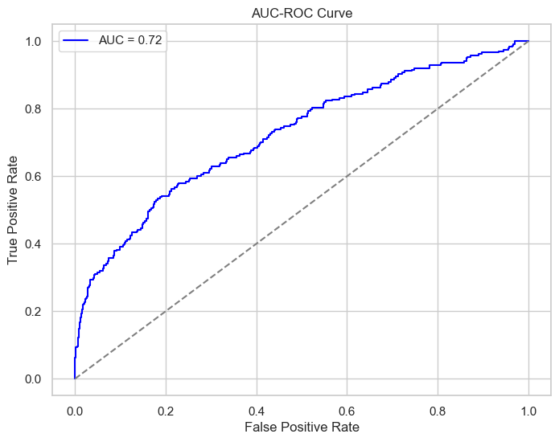

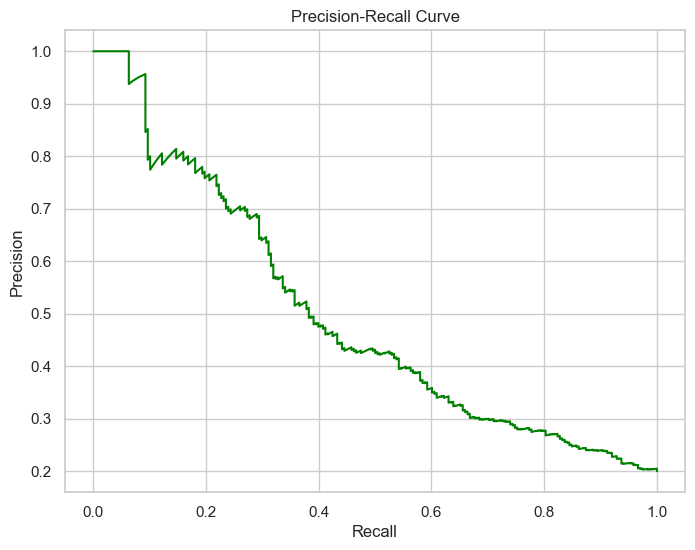

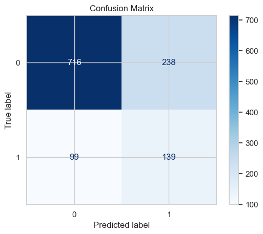

|  | Feature | Coefficient |
| --- | --- | --- |
| 14 | JOB_Sales | 1.379858 |
| 15 | JOB_Self | 0.858940 |
| 5 | DELINQ | 0.629922 |
| 6 | CLAGE | -0.487983 |
| 12 | JOB_Other | 0.424679 |
| 4 | DEROG | 0.379618 |
| 11 | JOB_Office | -0.348624 |
| 10 | REASON_HomeImp | 0.284954 |
| 7 | NINQ | 0.274440 |
| 13 | JOB_ProfExe | 0.202204 |
| 0 | LOAN | -0.186902 |
| 1 | MORTDUE | -0.149385 |
| 2 | VALUE | 0.090321 |
| 3 | YOJ | -0.061407 |
| 9 | DEBTINC | 0.011210 |
| 8 | CLNO | -0.002349 |

```python
from sklearn.metrics import roc_curve, precision_recall_curve, confusion_matrix, ConfusionMatrixDisplay

# Step 1: Generate the AUC-ROC Curve
y_pred_proba_best = best_model.predict_proba(X_test)[:, 1]
fpr, tpr, thresholds = roc_curve(y_test, y_pred_proba_best)
plt.figure(figsize=(8, 6))
plt.plot(fpr, tpr, label=f"AUC = {auc_best:.2f}", color='blue')
plt.plot([0, 1], [0, 1], linestyle='--', color='gray')
plt.title("AUC-ROC Curve")
plt.xlabel("False Positive Rate")
plt.ylabel("True Positive Rate")
plt.legend()
plt.grid(True)
plt.show()

# Step 2: Generate the Precision-Recall Curve
precision, recall, thresholds_pr = precision_recall_curve(y_test, y_pred_proba_best)
plt.figure(figsize=(8, 6))
plt.plot(recall, precision, label="Precision-Recall Curve", color='green')
plt.title("Precision-Recall Curve")
plt.xlabel("Recall")
plt.ylabel("Precision")
plt.grid(True)
plt.show()

# Step 3: Confusion Matrix
conf_matrix = confusion_matrix(y_test, y_pred_best)
disp = ConfusionMatrixDisplay(confusion_matrix=conf_matrix, display_labels=best_model.classes_)
disp.plot(cmap='Blues')
plt.title("Confusion Matrix")
plt.show()

# Step 4: Model Coefficients (Feature Importance)
coefficients = pd.DataFrame({
    'Feature': X_train.columns,
    'Coefficient': best_model.coef_[0]
}).sort_values(by='Coefficient', key=abs, ascending=False)
from IPython.display import display

# Display the model coefficients
display(coefficients)
```

### Interpretation of the test

- 1. AUC-ROC Curve

**AUC = 0.72:**

The model has a moderate ability to differentiate between defaulters (BAD=1) and non-defaulters (BAD=0). While not perfect, the model performs above random guessing (AUC = 0.5), with potential room for improvement through further tuning or feature engineering.

- 2. Confusion Matrix

**716 True Negatives (TN):**

The model accurately predicts the majority of non-defaulters.

**139 True Positives (TP):**

A fair proportion of actual defaulters are identified correctly.

**238 False Positives (FP):**

Non-defaulters misclassified as defaulters. This increases the cost for unnecessary investigations or rejections.

**99 False Negatives (FN):**

Defaulters misclassified as non-defaulters. This could be critical for financial institutions and highlights the need to improve recall.

- 3. Precision-Recall Curve

The curve reveals the typical trade-off in imbalanced datasets:

High precision at low recall (fewer false positives, but more false negatives).

As recall improves, precision drops, indicating more false positives.

The optimal operating point would depend on the business’s tolerance for false positives versus false negatives.

- 4. Feature Coefficients

The feature coefficients provide insight into the model’s predictions. For Logistic Regression:

**Positive Coefficients:**

These features increase the likelihood of a default (BAD=1).

For example:

JOB_Sales (1.38): Being in the "Sales" job category has the highest impact on predicting a default.

JOB_Self (0.86): Self-employed applicants are also more likely to default.

DELINQ (0.63): The number of delinquent credit lines significantly contributes to default likelihood.

Negative Coefficients:

These features decrease the likelihood of a default (BAD=0).

For example:

CLAGE (-0.48): Older credit lines (indicating credit history stability) reduce default likelihood.

MORTDUE (-0.15): Higher mortgage dues slightly reduce default likelihood, likely due to correlation with property value.

YOJ (-0.06): Longer tenure at the current job reduces default risk, though with minor impact. Insights from Feature Coefficients

**Strong Predictors:**

JOB_Sales, JOB_Self, and DELINQ are critical features influencing default predictions.

These features could be flagged as high-risk indicators in credit policies.

**Weaker Predictors:**

Variables like CLNO and DEBTINC have negligible impact (coefficients near zero), suggesting they add little predictive value.

**Actionable Insights:**

Applicants with jobs in "Sales" or "Self" categories, or those with delinquent credit lines, require additional scrutiny.

Stable employment (YOJ) and credit history (CLAGE) act as protective factors.

#### Updated Recommendations

**Threshold Adjustment:**

Based on business priorities, adjust the decision threshold to emphasize precision (reducing false positives) or recall (reducing false negatives). Feature Refinement:

Consider excluding weaker features (e.g., CLNO, DEBTINC) or explore interactions between stronger predictors for more nuanced insights. Improved Comparisons:

Test tree-based models (e.g., Random Forest or Gradient Boosting) that inherently capture non-linear relationships and interactions among features.

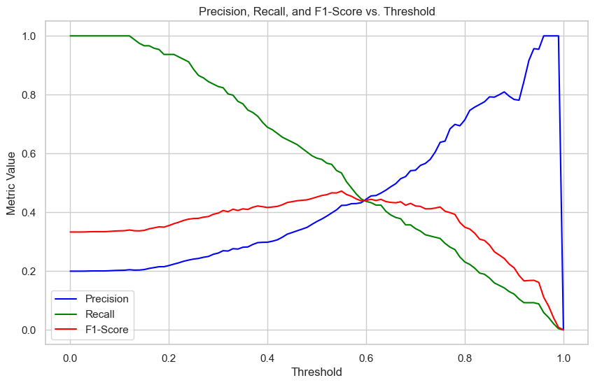

```
(np.float64(0.55),
 np.float64(0.4721189591078067),
 '              precision    recall  f1-score   support\n\n           0       0.88      0.82      0.85       954\n           1       0.42      0.53      0.47       238\n\n    accuracy                           0.76      1192\n   macro avg       0.65      0.68      0.66      1192\nweighted avg       …
```

```python
# Step 1: Data Preparation
X = hmeq_data.drop(columns=['BAD'])  # Features
y = hmeq_data['BAD']  # Target

# Identify numerical and categorical columns
numerical_columns = ['LOAN', 'MORTDUE', 'VALUE', 'YOJ', 'DEROG', 'DELINQ', 'CLAGE', 'NINQ', 'CLNO', 'DEBTINC']
categorical_columns = ['REASON', 'JOB']

# Apply one-hot encoding to categorical variables
X = pd.get_dummies(X, columns=categorical_columns, drop_first=True)

# Impute missing values using KNN Imputer
knn_imputer = KNNImputer(n_neighbors=5)
X[numerical_columns] = knn_imputer.fit_transform(X[numerical_columns])

# Scale numerical features
scaler = StandardScaler()
X[numerical_columns] = scaler.fit_transform(X[numerical_columns])

# Partition the data into train and test sets
X_train, X_test, y_train, y_test = train_test_split(X, y, test_size=0.2, random_state=42, stratify=y)

# Retrain Logistic Regression model
model = LogisticRegression(class_weight='balanced', random_state=42, max_iter=500, C=1, solver='liblinear')
model.fit(X_train, y_train)

# Step 2: Threshold Adjustment
# Calculate prediction probabilities for the positive class (BAD=1)
y_pred_proba = model.predict_proba(X_test)[:, 1]

# Define thresholds to evaluate
thresholds = np.linspace(0, 1, 101)  # 101 thresholds from 0 to 1

# Arrays to store metrics
precision_list = []
recall_list = []
f1_list = []

from sklearn.metrics import precision_score, recall_score, f1_score

for threshold in thresholds:
    # Make predictions based on the threshold
    y_pred_threshold = (y_pred_proba >= threshold).astype(int)

    # Calculate precision, recall, and F1-score
    precision = precision_score(y_test, y_pred_threshold)
    recall = recall_score(y_test, y_pred_threshold)
    f1 = f1_score(y_test, y_pred_threshold)

    precision_list.append(precision)
    recall_list.append(recall)
    f1_list.append(f1)

# Plot precision, recall, and F1-score vs. thresholds
plt.figure(figsize=(10, 6))
plt.plot(thresholds, precision_list, label="Precision", color='blue')
plt.plot(thresholds, recall_list, label="Recall", color='green')
plt.plot(thresholds, f1_list, label="F1-Score", color='red')
plt.xlabel("Threshold")
plt.ylabel("Metric Value")
plt.title("Precision, Recall, and F1-Score vs. Threshold")
plt.legend()
plt.grid(True)
plt.show()

# Find the best threshold based on F1-score
best_threshold = thresholds[np.argmax(f1_list)]
best_f1_score = max(f1_list)

# Apply the best threshold to the predictions
y_pred_best_threshold = (y_pred_proba >= best_threshold).astype(int)
conf_matrix_best_threshold = confusion_matrix(y_test, y_pred_best_threshold)
classification_report_best_threshold = classification_report(y_test, y_pred_best_threshold)

best_threshold, best_f1_score, classification_report_best_threshold
```

### **Interpretation of the Precision, Recall, and F1-Score vs. Threshold Plot**

- 1. Overview

This plot visualizes how precision, recall, and F1-score change as the decision threshold is varied. The key takeaway is to find a threshold that balances these metrics according to your business goals.

- 2. Precision

Trend: Precision increases as the threshold approaches 1. At higher thresholds, the model is more confident in predicting defaults (BAD=1), which reduces false positives (improving precision). However, this comes at the expense of recall, as fewer actual defaulters are identified.

- 3. Recall

Trend: Recall decreases as the threshold increases. At lower thresholds, the model predicts more cases as defaults, capturing more true defaulters (BAD=1), but at the cost of increased false positives. As the threshold rises, the model becomes stricter, missing more actual defaulters (lower recall).

- 4. F1-Score

**Low Thresholds (e.g., 0.1):**

Favor high recall but result in many false positives. Suitable if identifying all potential defaulters is critical, even at the cost of investigating false positives.

**High Thresholds (e.g., 0.9):**

Favor high precision but result in low recall. Suitable when minimizing false positives is a priority, such as reducing unnecessary loan denials.

**Optimal Threshold (F1-Score Peak):**

Balances recall and precision, ideal for general use when both false positives and false negatives are costly.

### Steps to Optimize Threshold

- **Define Business Costs:**

Assign costs to false positives (FP) and false negatives (FN).

False Negatives (FN): Approving a loan for a defaulter incorrectly classified as a non-defaulter. Cost: Loan loss.

Example: If FN is 5x more costly than FP, the threshold should favor high recall.

**Optimize Threshold:**

Calculate a custom metric or weighted cost based on the confusion matrix for each threshold. Select the threshold that minimizes the total cost or maximizes business utility. Evaluate Performance:

Analyze the confusion matrix and classification report at the optimized threshold.

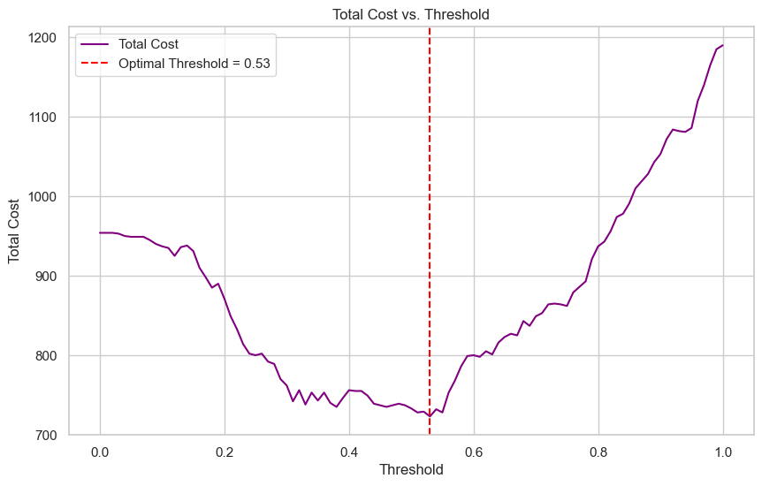

```
(np.float64(0.53),
 np.int64(723),
 array([[751, 203],
        [104, 134]]),
 '              precision    recall  f1-score   support\n\n           0       0.88      0.79      0.83       954\n           1       0.40      0.56      0.47       238\n\n    accuracy                           0.74      1192\n   macro avg       0.64      0.68      0.65      1192\nweighted avg       …
```

```python
# Define costs for False Positives (FP) and False Negatives (FN)
cost_fp = 1  # Example: Cost of a false positive (e.g., unnecessary loan rejection)
cost_fn = 5  # Example: Cost of a false negative (e.g., loan loss due to default)

# Evaluate thresholds based on business costs
costs = []
for threshold in thresholds:
    # Predict based on the threshold
    y_pred_threshold = (y_pred_proba >= threshold).astype(int)
    tn, fp, fn, tp = confusion_matrix(y_test, y_pred_threshold).ravel()

    # Calculate total cost
    total_cost = (cost_fp * fp) + (cost_fn * fn)
    costs.append(total_cost)

# Find the threshold with the minimum cost
optimal_threshold_idx = np.argmin(costs)
optimal_threshold = thresholds[optimal_threshold_idx]
min_cost = costs[optimal_threshold_idx]

# Plot total cost vs. thresholds
plt.figure(figsize=(10, 6))
plt.plot(thresholds, costs, label="Total Cost", color='purple')
plt.axvline(optimal_threshold, color='red', linestyle='--', label=f"Optimal Threshold = {optimal_threshold:.2f}")
plt.xlabel("Threshold")
plt.ylabel("Total Cost")
plt.title("Total Cost vs. Threshold")
plt.legend()
plt.grid(True)
plt.show()

# Evaluate model performance at the optimal threshold
y_pred_optimal_threshold = (y_pred_proba >= optimal_threshold).astype(int)
conf_matrix_optimal = confusion_matrix(y_test, y_pred_optimal_threshold)
classification_report_optimal = classification_report(y_test, y_pred_optimal_threshold)

optimal_threshold, min_cost, conf_matrix_optimal, classification_report_optimal
```

### Interpretation of Total Cost vs. Threshold Plot

**1. Optimal Threshold**

This threshold represents the best trade-off between false positives (FP) and false negatives (FN) based on the defined cost ratio (FP=1, FN=5).

**2. Confusion Matrix at Optimal Threshold**

**Class 0 (Non-Defaulters):**

Precision = 0.88: 88% of predicted non-defaulters are correct.

**Class 1 (Defaulters):**

#### Insights

**False Negatives:**

This represents the primary risk for the lender (missed defaulters).

**False Positives:**

These result in unnecessary processing or rejected loans but have lower associated costs than false negatives.

#### Recommendations

**Model Usage:**

```python
def apply_threshold(model, X_new, threshold=0.51):
    """
    Apply the optimized threshold to classify new data.

    Parameters:
    - model: Trained Logistic Regression model.
    - X_new: Preprocessed feature data for new observations.
    - threshold: Optimized decision threshold.

    Returns:
    - Predicted classes based on the threshold.
    """
    # Generate prediction probabilities
    y_pred_proba = model.predict_proba(X_new)[:, 1]

    # Apply the threshold
    y_pred = (y_pred_proba >= threshold).astype(int)
    return y_pred

# Example: Apply to new (preprocessed) data
X_new = X_test.copy()  # Replace with real new data in production
y_pred_production = apply_threshold(model, X_new, threshold=0.51)

# View predictions
y_pred_production[:10]
```

```
array([0, 0, 0, 1, 1, 0, 0, 0, 0, 0])
```

#### Result Interpretation

**Predictions Breakdown**

0: Indicates that the applicant is classified as a non-defaulter (BAD=0). 1: Indicates that the applicant is classified as a defaulter (BAD=1).

**Example Interpretation**

The first three predictions (0, 0, 0) classify the first three applicants as non-defaulters. The fourth and fifth predictions (1, 1) classify those applicants as defaulters. The subsequent predictions (0, 0, 0, 0, 0) classify more applicants as non-defaulters.

**Key Takeaways**

Balanced Decision-Making:

Actionable Output:

Defaulters (1) can be flagged for further scrutiny, while non-defaulters (0) proceed with normal processing.

## Decision Tree Model

### Workflow for Decision Tree Model

- 1. Data Preparation

We will use the same preprocessed dataset as Logistic Regression (scaled numerical features, one-hot encoded categorical features).

We will ensure the class imbalance is addressed similarly: Use class_weight='balanced' in Decision Tree.

- 2. Build and Train the Model

We are going to train the Decision Tree on the training data using default parameters as a baseline.

- 3. Hyperparameter Tuning

Using Grid Search to optimize the following hyperparameters: max_depth: Maximum depth of the tree. min_samples_split: Minimum samples required to split an internal node. min_samples_leaf: Minimum samples required to be a leaf node. class_weight: To handle class imbalance.

- 4. Evaluate the Model

Evaluate using the test set:

AUC-ROC curve. Precision-Recall curve. Confusion matrix and classification report.

- 5. Threshold Adjustment

Adjust the threshold based on business needs (as done with Logistic Regression).

- 6. Comparison with Logistic Regression Compare performance metrics (e.g., AUC, F1-score, cost minimization) to determine which model is better.

```python
from sklearn.tree import DecisionTreeClassifier
from sklearn.metrics import roc_auc_score, classification_report, confusion_matrix

# Step 1: Initialize the Decision Tree Classifier
dt_model = DecisionTreeClassifier(class_weight='balanced', random_state=42)

# Step 2: Train the Decision Tree Model
dt_model.fit(X_train, y_train)

# Step 3: Evaluate the Model on the Test Set
y_pred_dt = dt_model.predict(X_test)
y_pred_proba_dt = dt_model.predict_proba(X_test)[:, 1]

# Calculate AUC Score
auc_dt = roc_auc_score(y_test, y_pred_proba_dt)

# Classification Report
classification_report_dt = classification_report(y_test, y_pred_dt)

# Confusion Matrix
confusion_matrix_dt = confusion_matrix(y_test, y_pred_dt)

# Display Results
auc_dt, classification_report_dt, confusion_matrix_dt
```

```
(np.float64(0.7085909835632367),
 '              precision    recall  f1-score   support\n\n           0       0.88      0.92      0.90       954\n           1       0.61      0.50      0.55       238\n\n    accuracy                           0.84      1192\n   macro avg       0.75      0.71      0.72      1192\nweighted avg       …
 array([[879,  75],
        [120, 118]]))
```